# R Solo Project - Habeeb

```r
# Read in tidyverse and readxl libraries
library(tidyverse)
library(readxl)

# Prevent scientific notation in graphs
options(scipen = 100)
```

Question 1: Read in ‘districts.csv’ into a tibble named ‘districts’. How many rows and columns does it contain?

Answer: The data set contains 146 rows and 27 columns.

```r
districts <- read_csv('../data/districts.csv')
```

Question 2: Notice that the first row corresponds to the whole State of Tennessee. Remove this row and save the result back to ‘districts’.

```r
districts <- districts %>%
  filter(system_name != "State of Tennessee")
```

Question 3: How many districts have a proficiency rate of at least 80% for both alg_1 and eng_1?

Answer: 13 districts have a proficiency rate of at least 80% for both Algebra 1 and English 1.

```r
districts %>%
  filter(alg_1 >= 80 & eng_1 >= 80) %>%
  summarize(n_distinct(system_name))
```

| n_distinct(system_name) |
| --- |
| 13 |

Question 4: How many districts have a proficiency rate less than 50% for either alg_1 or eng_1?

Answer: 8 districts have a proficiency rate less than 50% for either Algebra 1 or English 1.

```r
districts %>%
  filter(alg_1 < 50 | eng_1 < 50) %>%
  summarize(n_distinct(system_name))
```

| n_distinct(system_name) |
| --- |
| 8 |

Question 5: Which district has the lowest graduation rate?

Answer: Tennessee School for the Blind has the lowest graduation rate at 11.1%.

```r
districts %>%
  filter(grad == min(grad, na.rm=TRUE)) %>%
  select(system_name, grad)
```

| system_name | grad |
| --- | --- |
| Tenn School for Blind | 11.1 |

Question 6: Which district has the highest dropout rate?

Answer: Achievement School District has the highest dropout rate at 27.6%.

```r
districts %>%
  filter(dropout == max(dropout, na.rm=TRUE)) %>%
  select(system_name, dropout)
```

| system_name | dropout |
| --- | --- |
| Achievement School District | 27.6 |

Question 7: Within the Mid Cumberland region, which district has the highest ACT composite?

Answer: Williamson County has the highest ACT composite score within the Mid Cumberland region.

```r
districts %>%
  filter(region == "Mid Cumberland") %>%
  filter(act_composite == max(act_composite, na.rm=TRUE)) %>%
  select(system_name, act_composite)
```

| system_name | act_composite |
| --- | --- |
| Williamson County | 23.8 |

Question 8: Create a histogram showing the distribution of graduation rates. What can you say about this distribution?

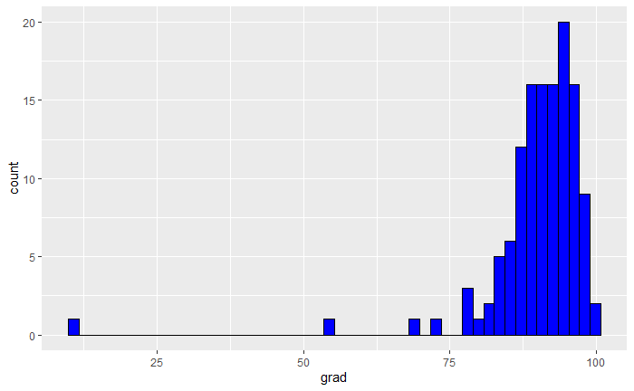

```r
ggplot(districts, aes(x = grad)) +
  geom_histogram(bins = 50, fill = "blue", color = "black")
```

Question 9: Create a scatter plot to compare alg_1 proficiency rates to alg_2 rates. What do you notice? Facet this plot by region. Does anything stand out when you facet the plots?

Answer: The scatter plot comparing the proficiency rates between Algebra 1 and Algebra 2 shows a positive correlation between the two variables. Once faceting the data by region, we see a neutral correlation in the Upper Cumberland region.

```
Warning: Removed 28 rows containing non-finite values (stat_smooth).
Warning: Removed 28 rows containing missing values (geom_point).
```

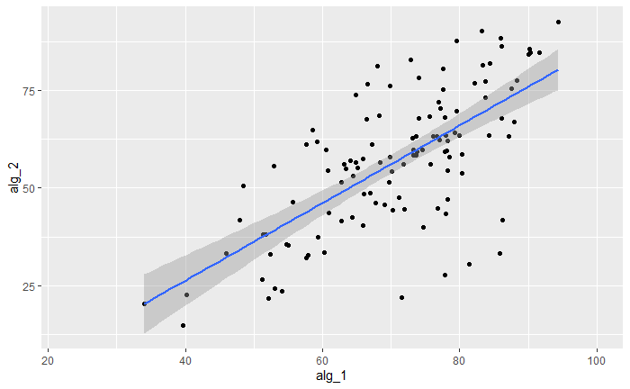

```r
ggplot(districts, aes(x = alg_1, y = alg_2)) +
  geom_point() +
  geom_smooth(method = "lm")
```

```
Warning: Removed 28 rows containing non-finite values (stat_smooth).
Warning: Removed 28 rows containing missing values (geom_point).
```

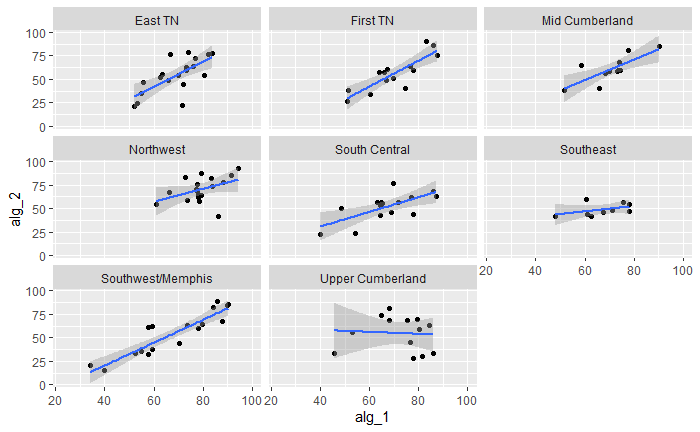

```r
ggplot(districts, aes(x = alg_1, y = alg_2)) +
  geom_point() +
  facet_wrap(~region) +
  geom_smooth(method = "lm")
```

Question 10: Create a bar chart showing the total enrollment by region. Which region has the highest total enrollment? Which has the smallest?

Answer: Mid Cumberland is the region with the highest total enrollment, while the Northwest region had the lowest total enrollment.

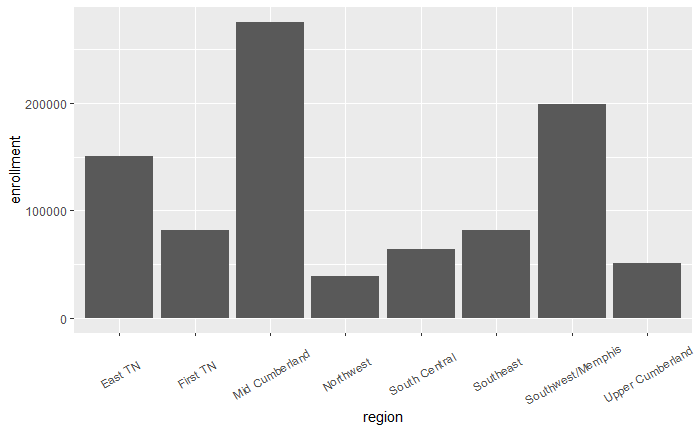

```r
ggplot(districts, aes(x = region, y = enrollment)) +
  geom_col() +
  theme(axis.text.x = element_text(angle = 30, vjust = 0.5, hjust = 0.5))
```

Question 11: When creating this bar chart you may have noticed that some districts have missing enrollment values. For how many districts is this the case?

Answer: There are 4 districts with missing enrollment values.

```r
districts %>%
  filter(is.na(enrollment)) %>%
  count()
```

| n |
| --- |
| 4 |

Question 12: What is the mean graduation rate across all districts? What might be wrong with using just the regular mean to assess average graduation rates?

Answer: The mean graduation across all the districts is 90.07. The normal mean is thrown off by the very low graduation rate of the Tennessee School of the Blind.

```r
districts %>%
  summarize(mean(grad, na.rm = TRUE))
```

| mean(grad, na.rm = TRUE) |
| --- |
| 90.06562 |

Question 13: Redo the previous question but use a weighted average (`weighted.mean`) graduation across all districts, weighing by enrollment. How much does this change your answer? Can you explain using the data the reason for the big change from using the mean?

Answer: The weighted mean is 87.33. It is 3 points lower than the non-weighted mean. Looking at the above scatter plot we can see that most of the points are gathered around the lower right hand side of the graph, meaning most districts had graduation rates above 75% with enrollment below 15000. The outliers with high enrollment rates but lower graduation rates more than likely caused the weighted mean to be lower than the non-weighted mean.

```r
districts %>%
  filter(is.na(enrollment) == FALSE) %>%
  summarize(weighted_mean = weighted.mean(grad, enrollment, na.rm = TRUE))
```

| weighted_mean |
| --- |
| 87.33285 |

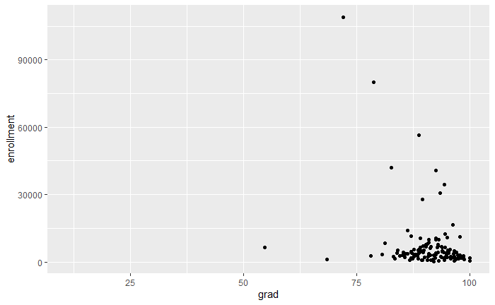

```r
ggplot(districts, aes(x = grad, y = enrollment)) +
  geom_point()
```

Question 14: Create a boxplot showing enrollment rates per region. Does anything stand out?

Answer: 50% of the schools in most regions have around the same enrollment rate. The only exception to this is the Mid Cumberland region where 50% of schools have an enrollment rate between 3544 and 29197.

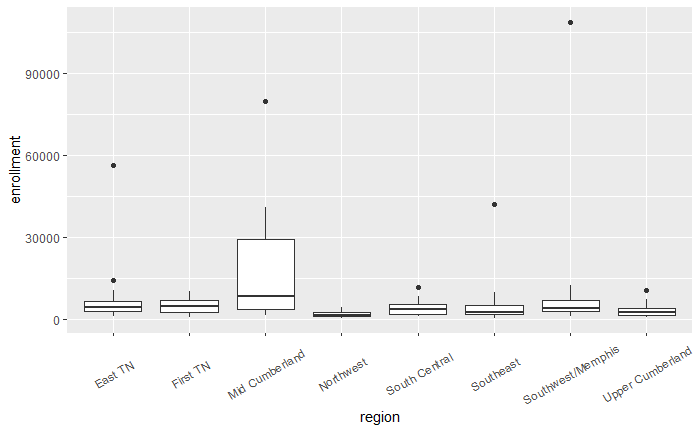

```r
ggplot(districts, aes(x = region, y = enrollment)) +
  geom_boxplot() +
  theme(axis.text.x = element_text(angle = 30, vjust = 0.5, hjust = 0.5))
```

```r
districts %>%
  filter(region == "Mid Cumberland") %>%
  summarise(first_quartile = quantile(enrollment, 0.25, na.rm=TRUE), third__quartile = quantile(enrollment, 0.75, na.rm=TRUE))
```

| first_quartile | third__quartile |
| --- | --- |
| 3543.5 | 29197 |

Question 15: Create a boxplot showing graduation rates per region. Does anything stand out?

Answer: The median and IQR of the graduation rates across the regions are all pretty high (above 75%). The Mid Cumberland region is interesting because it has a very low outlier caused by Tennessee School of the Blind.

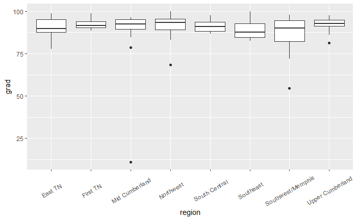

```r
ggplot(districts, aes(x = region, y = grad)) +
  geom_boxplot() +
  theme(axis.text.x = element_text(angle = 30, vjust = 0.5, hjust = 0.5))
```

Question 16: Find the weighted average of graduation rates by region using enrollment as weights. Compare the results you get for the weighted average to what you see from the boxplots. Can you explain any discrepancy?

Answer:

```r
districts %>%
  group_by(region) %>%
  filter(is.na(enrollment) == FALSE) %>%
  summarize(weighted_mean = weighted.mean(grad, enrollment, na.rm = TRUE))
```

| region | weighted_mean |
| --- | --- |
| East TN | 89.87089 |
| First TN | 91.91454 |
| Mid Cumberland | 88.53965 |
| Northwest | 91.57705 |
| South Central | 90.47392 |
| Southeast | 85.95494 |
| Southwest/Memphis | 79.45971 |
| Upper Cumberland | 92.24062 |

Question 17: For many districts, values for `alg_2` are lower than for `alg_1`. Create a histogram showing the distribution of differences (`alg_1` - `alg_2`). Which school had the largest drop from `alg_1` to `alg_2`? For what percentage of schools is it true that `alg_2` is larger than `alg_1`? Is there a similar dropoff for `eng_2` and `eng_3`?

Answer: Pickett County has the largest drop from Algebra 1 to Algebra 2, from 85.9 to 33.3. Roughly 12% of districts (18 districts) have Algebra 2 scores that are higher than their Algebra 1 scores. There is a worse trend seen in the difference between English 2 and English 3. There is only 1 district, Bradford SSD, that has a higher English 3 score then their English 2 score.

```
Warning: Removed 28 rows containing non-finite values (stat_bin).
```

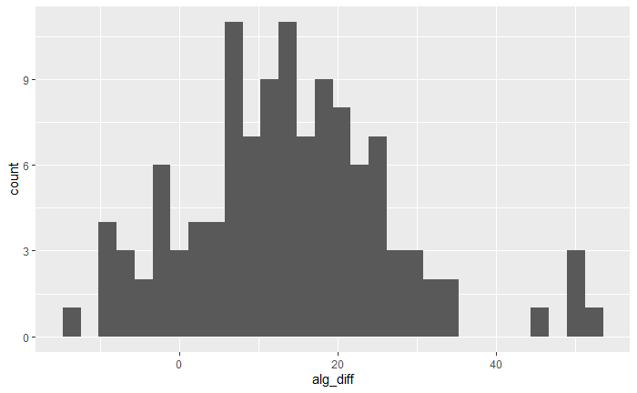

```r
sub_sec <- districts %>%
  select(system_name, alg_1, alg_2, eng_2, eng_3) %>%
  mutate(alg_diff = alg_1 - alg_2, eng_diff = eng_2 - eng_3)

ggplot(sub_sec, aes(x = alg_diff)) +
  geom_histogram()
```

```r
sub_sec %>%
  filter(alg_diff == max(alg_diff, na.rm = TRUE))
```

| system_name | alg_1 | alg_2 | eng_2 | eng_3 | alg_diff | eng_diff |
| --- | --- | --- | --- | --- | --- | --- |
| Pickett County | 85.9 | 33.3 | 65.2 | 29.1 | 52.6 | 36.1 |

```r
sub_sec %>%
  filter(alg_diff < 0) %>%
  summarize(alg_2_greater_alg_1 = n() / nrow(districts) * 100)
```

| alg_2_greater_alg_1 |
| --- |
| 12.41379 |

```
Warning: Removed 19 rows containing non-finite values (stat_bin).
```

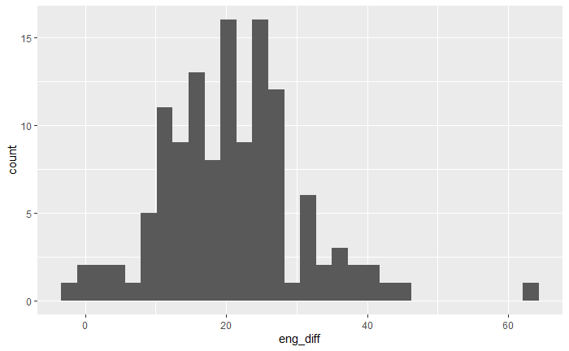

```r
ggplot(sub_sec, aes(x = eng_diff)) +
  geom_histogram()
```

```r
sub_sec %>%
  filter(eng_diff == max(eng_diff, na.rm = TRUE))
```

| system_name | alg_1 | alg_2 | eng_2 | eng_3 | alg_diff | eng_diff |
| --- | --- | --- | --- | --- | --- | --- |
| Richard City | 78.3 | 54.5 | 88.5 | 25 | 23.8 | 63.5 |

```r
sub_sec %>%
  filter(eng_diff < 0) %>%
  summarize(eng_3_greater_eng_2 = n() / nrow(districts) *100)
```

| eng_3_greater_eng_2 |
| --- |
| 0.6896552 |

Question 18: You may have noticed that a lot of rows are missing values. Which district has the largest number of missing values? What do you notice about schools that have a lot of missing values?

Answer: West Tennessee School for the Deaf has the most missing values. All regions have at least one district that has a NA value. The school districts with missing values all have their expulsion rate recorded and they have a very low to no expulsion rate.

```r
districts %>%
  rowwise() %>%
  mutate(NA_per_row = sum(is.na(cur_data()))) %>%
  filter(NA_per_row > 0) %>% View()
```

Question 19: Find the correlation between graduation rate and all other variables. Create a horizontal bar chart showing these correlations. Make sure that your plot is ordered by correlation values. What do you notice from these correlations?

Answer: Unsurprisingly graduation rate has a strong, negative correlation with dropout and suspension rates. There is also positive correlations between graduation rate and proficiency and ACT test scores.

```r
grad_corr <- districts %>%
  select(where(is.numeric) & !system) %>%
  cor(use = "complete.obs")
```

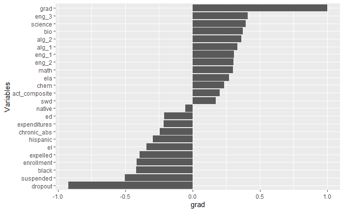

```r
corr_plot <- as.data.frame(grad_corr) %>%
  ggplot(aes(x = reorder(rownames(grad_corr), grad), y = grad)) +
  geom_col()

corr_plot +
  coord_flip() +
  labs(x = "Variables")
```

Question 20: Create a scatterplot for `grad` vs. `suspended`. Does what you see make sense given your answer from the previous part?

Answer: The scatter plot does make sense, per the bar plot from the previous graph. As we see an increase in suspension rate, we see the graduation rate decrease.

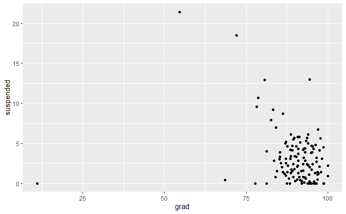

```r
grad_suspeded_scatter <- ggplot(districts, aes(x = grad, y = suspended)) +
  geom_point()
grad_suspeded_scatter
```

Question 21: Create a linear regression model using `lm` with target variable `grad` and predictor variable `suspended`. What R^2 value does this model have? What is the interpretation of this number?

Answer: The R^2 value for this linear regression model is 0.0795. This means that the suspension rate explains about 7.95% of the variability seen in the graduation rate.

```r
simple_regression_model <- lm(grad ~ suspended, data = districts)

summary(simple_regression_model)
```

```
Call:
lm(formula = grad ~ suspended, data = districts)

Residuals:
    Min      1Q  Median      3Q     Max
-81.407  -2.271   1.190   3.934  12.208

Coefficients:
            Estimate Std. Error t value             Pr(>|t|)
(Intercept)  92.5071     1.0924  84.679 < 0.0000000000000002 ***
suspended    -0.7858     0.2382  -3.299              0.00126 **
---
Signif. codes:  0 ‘***’ 0.001 ‘**’ 0.01 ‘*’ 0.05 ‘.’ 0.1 ‘ ’ 1

Residual standard error: 9.091 on 126 degrees of freedom
  (17 observations deleted due to missingness)
Multiple R-squared:  0.0795,    Adjusted R-squared:  0.0722
F-statistic: 10.88 on 1 and 126 DF,  p-value: 0.001262
```

Question 22: Add the regression line to your scatterplot using `geom_smooth` with `method='lm'`. How do you feel about the regression line after seeing it plotted on the scatterplot?

Answer: The regression line properly reflects the 7.95% of the variability we determined in the last problem.

```
Warning: Removed 17 rows containing non-finite values (stat_smooth).
Warning: Removed 17 rows containing missing values (geom_point).
```

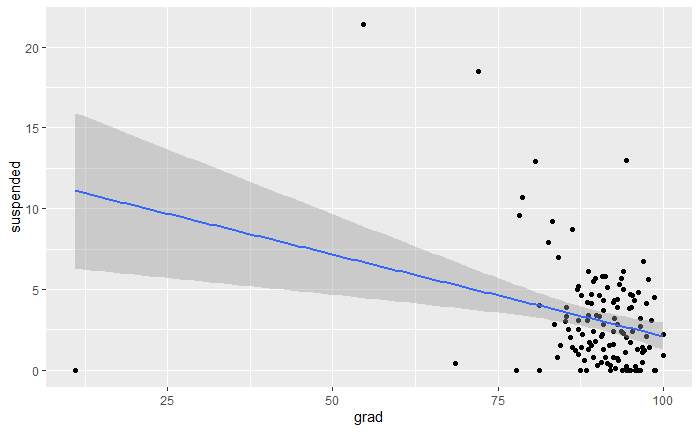

```r
grad_suspeded_scatter +
  geom_smooth(method='lm')
```

Question 23: ead in the school-level testing data for 2014, available [here](https://www.tn.gov/content/dam/tn/education/data/data_2014_school_base.xlsx). You might find the readxl library useful for this task. If you use this library, be sure to look at the `na` argument for the `read_excel` function.

```r
tn_school_2014 <- read_excel("../data/data_2014_school_base.xlsx", na = c("*", "**"))
```

Question 24: How many schools have at least 20 percent of students below bsc for Algebra I? Which districts do these schools belong to?

Answer: 71 schools have at least 20 percent of students below bsc for Algebra I. These schools belong to 30 districts listed in the table below.

```r
algebra_1_below_bsc <- tn_school_2014 %>%
  filter(subject == "Algebra I", subgroup == "All Students", grade == "All Grades", pct_below_bsc >= 20)

algebra_1_below_bsc %>%
  summarize(n())
```

| n() |
| --- |
| 71 |

```r
algebra_1_below_bsc %>%
  group_by(system_name) %>%
  summarize(n())
```

| system_name | n() |
| --- | --- |
| Achievement School District | 1 |
| Bedford County | 1 |
| Bledsoe County | 1 |
| Bradley County | 1 |
| Campbell County | 2 |
| Cheatham County | 2 |
| Claiborne County | 2 |
| Cumberland County | 1 |
| Davidson County | 8 |
| Fayette County | 1 |

[output cut: 20 more lines]

Question 25: How many schools have at least 20 percent of students below bsc for *both* Algebra I and English I?

Answer: Jellico High School is the only school with at least 20 percent students below bsc for both Algebra I and English I.

```r
tn_school_2014 %>%
  filter(subgroup == "All Students", grade == "All Grades", subject == c("Algebra I", "English I"), pct_below_bsc >= 20) %>%
  select(system_name, school, school_name, subject, pct_below_bsc) %>%
  group_by(school_name) %>%
  filter(n() > 1)
```

| system_name | school | school_name | subject | pct_below_bsc |
| --- | --- | --- | --- | --- |
| Campbell County | 75 | Jellico High School | Algebra I | 23.2 |
| Campbell County | 75 | Jellico High School | English I | 21.3 |
| Hollow Rock-Bruceton | 10 | Central High School | Algebra I | 22.2 |
| Knox County | 47 | Central High School | Algebra I | 30.1 |
| Morgan County | 15 | Central High School | Algebra I | 36.6 |

```r
NA
```

Question 26: Which grade has the highest pct_adv for Algebra I? Plot the average pct_adv per grade level as a bar chart. Make sure that the bars are ordered by grade level.

Answer: Grade 8 has the highest pct_adv for Algebra I

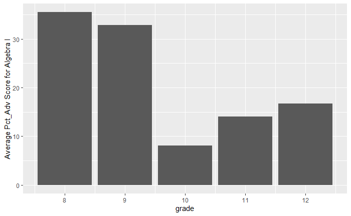

```r
tn_school_2014 %>%
  filter(subject == "Algebra I", grade != "All Grades", subgroup == "All Students") %>%
  group_by(grade) %>%
  summarize(algebra_1_pct_adv_mean = mean(pct_adv, na.rm = TRUE)) %>%
  drop_na() %>%
  mutate(grade = as.integer(grade)) %>%
  arrange(grade) %>%
  ggplot(aes(x = grade, y = algebra_1_pct_adv_mean)) +
  geom_col() +
  labs(y = "Average Pct_Adv Score for Algebra I")
```

Question 27: Find the correlation between pct_adv for Algebra I and pct_adv for Algebra II by school. Create a scatter plot showing Algebra II scores vs. Algebra I scores by school.

Answer:

```r
tn_school_2014 %>%
  filter(subject == c("Algebra I", "Algebra II"), grade == "All Grades", subgroup == "All Students") %>%
  select(school_name, subject, pct_adv) %>%
  group_by(school_name) %>%
  pivot_wider(names_from = school_name, values_from = pct_adv)
```

[output not shown]

Question 28: Find all schools in Rutherford County that have “High School” in their name. For these schools, create a chart (your choice) showing the differences in pct_below_bsc, pct_bsc, pct_prof, and pct_adv for Algebra I when looking across all subgroups and grades.

Answer:

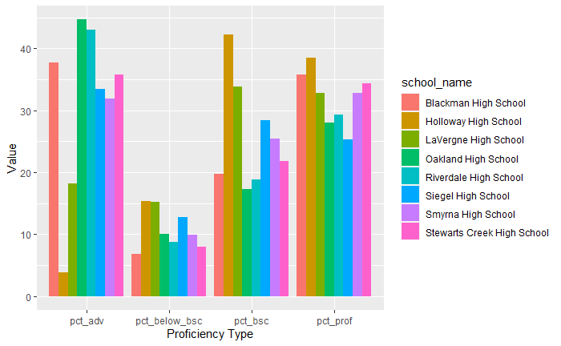

```r
tn_school_2014 %>%
  filter(system_name == "Rutherford County", grepl("High School", school_name), grade == "All Grades", subgroup == "All Students", subject == "Algebra I") %>%
  select(school_name, pct_below_bsc, pct_bsc, pct_prof, pct_adv) %>%
  gather(key = pct, value = Value, pct_below_bsc:pct_adv) %>%
  ggplot(aes(x = pct, y = Value, fill = school_name)) +
  geom_col(position = "dodge") +
  labs(x = "Proficiency Type")
```

Question 29: I claim that smaller schools do a better job preparing students for Algebra I standardized tests. Find the average number of valid tests (a proxy for the school size) for schools where the pct_prof_adv for Algebra I is greater than 95. Compare this to the average number of valid tests for all schools. In light of this result, how does my claim look?

```r
tn_school_2014 %>%
  filter(grade == "All Grades", subgroup == "All Students", subject == "Algebra I", pct_prof_adv > 95) %>%
  summarize(avg_valid_tests_smaller_schools = mean(valid_tests))
```

| avg_valid_tests_smaller_schools |
| --- |
| 48.44578 |

```r
tn_school_2014 %>%
  filter(grade == "All Grades", subgroup == "All Students", subject == "Algebra I") %>%
  summarize(avg_valid_tests_all_schools = mean(valid_tests))
```

| avg_valid_tests_all_schools |
| --- |
| 129.9502 |

Question 30: I also claim that smaller schools do a worse job preparing students for Algebra I standardized tests. Find the average number of valid tests (a proxy for the school size) for schools where the pct_prof_adv for Algebra I is less than 25. Compare this to the average number of valid tests for all schools. In light of this result, how does my claim look now?

Answer: This claim also seems to be valid. The average school size for schools that had a advanced proficiency rate of 25% or less in Algebra I was roughly 62 students. The average size for all schools that had students take an Algebra I test was roughly 130 students.

```r
tn_school_2014 %>%
  filter(grade == "All Grades", subgroup == "All Students", subject == "Algebra I", pct_prof_adv < 25) %>%
  summarize(avg_valid_tests_smaller_schools = mean(valid_tests))
```

| avg_valid_tests_smaller_schools |
| --- |
| 62.08696 |

```r
tn_school_2014 %>%
  filter(grade == "All Grades", subgroup == "All Students", subject == "Algebra I") %>%
  summarize(avg_valid_tests_all_schools = mean(valid_tests))
```

| avg_valid_tests_all_schools |
| --- |
| 129.9502 |

Question 31: Create a scatter plot showing pct_prof_adv vs. valid_tests. Can you use this to explain the result for numbers 29 and 30?

```
Warning: Removed 40 rows containing non-finite values (stat_smooth).
Warning: Removed 40 rows containing missing values (geom_point).
```

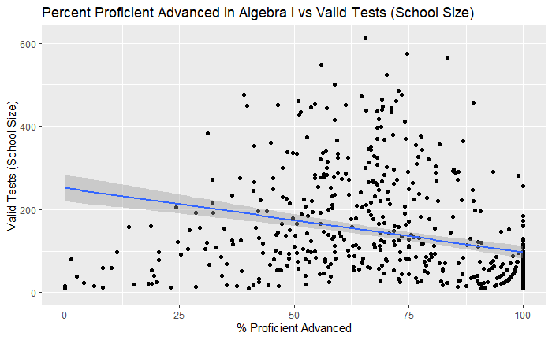

```r
tn_school_2014 %>%
  filter(grade == "All Grades", subgroup == "All Students", subject == "Algebra I") %>%
  ggplot(aes(x = pct_prof_adv, y = valid_tests)) +
  geom_point() +
  geom_smooth(method = "lm") +
  labs(title = "Percent Proficient Advanced in Algebra I vs Valid Tests (School Size)",
       x = "% Proficient Advanced",
       y = "Valid Tests (School Size)")
```